# Data Manipulation Tutorial - Datafest 2019

Vlad Achimescu

May 3, 2019

## IMPORT DATA

Read data as a tibble, using read_csv or read_tsv.

Read employment dataset

```r
EMP = read_tsv("empl_rates_reg.tsv")
EMP
```

```
## # A tibble: 1,014 x 16
##    unit  sex   age    geo   Y2007 Y2008 Y2009 Y2010 Y2011 Y2012 Y2013 Y2014
##    <chr> <chr> <chr>  <chr> <dbl> <dbl> <dbl> <dbl> <dbl> <dbl> <dbl> <dbl>
##  1 PC    F     Y15-64 AT_11  64    64.2  64.7  64.8  64.5  64.8  64.9  64.7
##  2 PC    F     Y15-64 AT_12  65.3  66.6  66.7  66.9  67.4  68.1  67.6  68.4
##  3 PC    F     Y15-64 AT_13  59.7  61.1  61.8  62    62.4  62.5  63    62.1
##  4 PC    F     Y15-64 AT_21  60.2  61.6  62.2  62.9  63.1  64.1  64.8  65.3
##  5 PC    F     Y15-64 AT_22  63.2  64.8  64.9  65.9  66.3  65.6  66.1  66.3
##  6 PC    F     Y15-64 AT_31  65.9  67.5  67.2  68.3  68.8  70    69.4  70.1
##  7 PC    F     Y15-64 AT_32  66.6  67.1  68.2  67.8  68.8  70.2  70.9  69.4
##  8 PC    F     Y15-64 AT_33  64.8  66.1  67.1  67.4  67.3  68.6  69.7  69.9
##  9 PC    F     Y15-64 AT_34  63    64.1  65.2  65.4  65.6  67.3  68.2  69.4
## 10 PC    F     Y15-64 BE_10  48.3  48.4  49.3  48.7  48.6  48.6  48.5  49.8
## # ... with 1,004 more rows, and 4 more variables: Y2015 <dbl>,
## #   Y2016 <dbl>, Y2017 <dbl>, Y2018 <dbl>
```

Read education&training dataset

```r
TRAIN = read_csv("training_participation.csv")
TRAIN
```

```
## # A tibble: 1,140 x 7
##       no  TIME GEO     COUNTRY UNIT       SEX     Value
##    <int> <int> <chr>   <chr>   <chr>      <chr>   <dbl>
##  1    67  2009 Austria AT      Percentage Total    13.9
##  2    68  2009 Austria AT      Percentage Males    12.9
##  3    69  2009 Austria AT      Percentage Females  14.9
##  4   181  2010 Austria AT      Percentage Total    13.8
##  5   182  2010 Austria AT      Percentage Males    12.8
##  6   183  2010 Austria AT      Percentage Females  14.9
##  7   295  2011 Austria AT      Percentage Total    13.5
##  8   296  2011 Austria AT      Percentage Males    12.3
##  9   297  2011 Austria AT      Percentage Females  14.6
## 10   409  2012 Austria AT      Percentage Total    14.2
## # ... with 1,130 more rows
```

## CHAINING FUNCTIONS - PIPE OPERATOR

Example: summarise unemployment rate in 2018

```r
# Extract unemployment rates
unempl2018  = 100 - EMP$Y2018
summary(unempl2018)
```

```
##    Min. 1st Qu.  Median    Mean 3rd Qu.    Max.    NA's
##   11.70   24.30   29.60   32.31   37.42   87.30      30
```

```r
# Base R - chaining
paste("Result:", round(quantile(log(unempl2018,2),.25, na.rm = TRUE), 1))
```

```
## [1] "Result: 4.6"
```

```r
# Base R - separate operations
log_unempl   = log(unempl2018,2)
quant_unempl = quantile(log_unempl, .25, na.rm = TRUE)
round_quant = round(quant_unempl, 1)
paste("Result:", round_quant)
```

```
## [1] "Result: 4.6"
```

```r
# Magrittr - chaining using pipe
unempl2018 %>%
  log(2) %>%
  quantile(.25, na.rm = TRUE) %>%
  round(1) %>%
  paste("Result:",.)
```

```
## [1] "Result: 4.6"
```

```r
# Magrittr - one line
unempl2018 %>% log(2) %>% quantile(.25, na.rm = TRUE) %>% round(1) %>% paste("Result:",.)
```

```
## [1] "Result: 4.6"
```

EXERCISE: Create a table of relative frequencies, sorted by descending:

```r
#Base R:
cbind(round(rev(sort(prop.table(table(TRAIN$SEX)))),2))
```

```
##         [,1]
## Total   0.33
## Males   0.33
## Females 0.33
```

```r
#Translate code above using piping:
```

```r
### additional functions (aliases) useful for piping
?magrittr::extract
```

```
## starting httpd help server ... done
```

## Slice and filter

Slice

```
## # A tibble: 5 x 7
##      no  TIME GEO     COUNTRY UNIT       SEX     Value
##   <int> <int> <chr>   <chr>   <chr>      <chr>   <dbl>
## 1    67  2009 Austria AT      Percentage Total    13.9
## 2    68  2009 Austria AT      Percentage Males    12.9
## 3    69  2009 Austria AT      Percentage Females  14.9
## 4   181  2010 Austria AT      Percentage Total    13.8
## 5   182  2010 Austria AT      Percentage Males    12.8
```

```
## # A tibble: 5 x 7
##      no  TIME GEO     COUNTRY UNIT       SEX     Value
##   <int> <int> <chr>   <chr>   <chr>      <chr>   <dbl>
## 1    67  2009 Austria AT      Percentage Total    13.9
## 2    68  2009 Austria AT      Percentage Males    12.9
## 3    69  2009 Austria AT      Percentage Females  14.9
## 4   181  2010 Austria AT      Percentage Total    13.8
## 5   182  2010 Austria AT      Percentage Males    12.8
```

```
## # A tibble: 5 x 7
##      no  TIME GEO     COUNTRY UNIT       SEX     Value
##   <int> <int> <chr>   <chr>   <chr>      <chr>   <dbl>
## 1    67  2009 Austria AT      Percentage Total    13.9
## 2    68  2009 Austria AT      Percentage Males    12.9
## 3    69  2009 Austria AT      Percentage Females  14.9
## 4   181  2010 Austria AT      Percentage Total    13.8
## 5   182  2010 Austria AT      Percentage Males    12.8
```

Subset rows / filter(logical_condition)

```r
### Base R - select cases from 2018 with more than 30% training
TRAIN[TRAIN$Value>30 & TRAIN$TIME == 2018,]
```

```
## # A tibble: 5 x 7
##      no  TIME GEO         COUNTRY UNIT       SEX     Value
##   <int> <int> <chr>       <chr>   <chr>      <chr>   <dbl>
## 1  1113  2018 Finland     FI      Percentage Females  32.4
## 2  1116  2018 Sweden      SE      Percentage Females  36.1
## 3  1126  2018 Switzerland CH      Percentage Total    31.6
## 4  1127  2018 Switzerland CH      Percentage Males    32.4
## 5  1128  2018 Switzerland CH      Percentage Females  30.9
```

```r
### dplyr
TRAIN %>% filter(Value>30, TIME == 2018)
```

```
## # A tibble: 5 x 7
##      no  TIME GEO         COUNTRY UNIT       SEX     Value
##   <int> <int> <chr>       <chr>   <chr>      <chr>   <dbl>
## 1  1113  2018 Finland     FI      Percentage Females  32.4
## 2  1116  2018 Sweden      SE      Percentage Females  36.1
## 3  1126  2018 Switzerland CH      Percentage Total    31.6
## 4  1127  2018 Switzerland CH      Percentage Males    32.4
## 5  1128  2018 Switzerland CH      Percentage Females  30.9
```

Filter by strings - regular expressions / sets

```r
### Select all countries starting with the letter "C"
TRAIN %>% filter(grepl("^C",GEO))
```

```
## # A tibble: 90 x 7
##       no  TIME GEO     COUNTRY UNIT       SEX     Value
##    <int> <int> <chr>   <chr>   <chr>      <chr>   <dbl>
##  1    40  2009 Croatia HR      Percentage Total     3
##  2    41  2009 Croatia HR      Percentage Males     3.2
##  3    42  2009 Croatia HR      Percentage Females   2.9
##  4   154  2010 Croatia HR      Percentage Total     3
##  5   155  2010 Croatia HR      Percentage Males     3
##  6   156  2010 Croatia HR      Percentage Females   3
##  7   268  2011 Croatia HR      Percentage Total     3.1
##  8   269  2011 Croatia HR      Percentage Males     2.9
##  9   270  2011 Croatia HR      Percentage Females   3.3
## 10   382  2012 Croatia HR      Percentage Total     3.3
## # ... with 80 more rows
```

```r
### Select Slovakia and Slovenia
TRAIN %>% filter(GEO %in% c("Slovakia","Slovenia"))
```

```
## # A tibble: 60 x 7
##       no  TIME GEO      COUNTRY UNIT       SEX     Value
##    <int> <int> <chr>    <chr>   <chr>      <chr>   <dbl>
##  1    82  2009 Slovakia SK      Percentage Total     3.1
##  2    83  2009 Slovakia SK      Percentage Males     2.5
##  3    84  2009 Slovakia SK      Percentage Females   3.7
##  4   196  2010 Slovakia SK      Percentage Total     3.1
##  5   197  2010 Slovakia SK      Percentage Males     2.5
##  6   198  2010 Slovakia SK      Percentage Females   3.7
##  7   310  2011 Slovakia SK      Percentage Total     4.1
##  8   311  2011 Slovakia SK      Percentage Males     3.5
##  9   312  2011 Slovakia SK      Percentage Females   4.6
## 10   424  2012 Slovakia SK      Percentage Total     3.2
## # ... with 50 more rows
```

EXERCISE: select only data from 2018 and 2019 from Romania - total and save in new variable FILT

```r
#FILT = TRAIN %>% filter(insert_conditions_here)
```

## Subset variables/columns - select

Select function makes code similar to Stata

```r
### Base R - select first three variables
EMP[,1:3]
```

```
## # A tibble: 1,014 x 3
##    unit  sex   age
##    <chr> <chr> <chr>
##  1 PC    F     Y15-64
##  2 PC    F     Y15-64
##  3 PC    F     Y15-64
##  4 PC    F     Y15-64
##  5 PC    F     Y15-64
##  6 PC    F     Y15-64
##  7 PC    F     Y15-64
##  8 PC    F     Y15-64
##  9 PC    F     Y15-64
## 10 PC    F     Y15-64
## # ... with 1,004 more rows
```

```r
EMP[,c("unit", "sex", "age" )]
```

```
## # A tibble: 1,014 x 3
##    unit  sex   age
##    <chr> <chr> <chr>
##  1 PC    F     Y15-64
##  2 PC    F     Y15-64
##  3 PC    F     Y15-64
##  4 PC    F     Y15-64
##  5 PC    F     Y15-64
##  6 PC    F     Y15-64
##  7 PC    F     Y15-64
##  8 PC    F     Y15-64
##  9 PC    F     Y15-64
## 10 PC    F     Y15-64
## # ... with 1,004 more rows
```

```r
### dplyr
EMP %>% select(1:3)
```

```
## # A tibble: 1,014 x 3
##    unit  sex   age
##    <chr> <chr> <chr>
##  1 PC    F     Y15-64
##  2 PC    F     Y15-64
##  3 PC    F     Y15-64
##  4 PC    F     Y15-64
##  5 PC    F     Y15-64
##  6 PC    F     Y15-64
##  7 PC    F     Y15-64
##  8 PC    F     Y15-64
##  9 PC    F     Y15-64
## 10 PC    F     Y15-64
## # ... with 1,004 more rows
```

```r
EMP %>% select("unit", "sex", "age")
```

```
## # A tibble: 1,014 x 3
##    unit  sex   age
##    <chr> <chr> <chr>
##  1 PC    F     Y15-64
##  2 PC    F     Y15-64
##  3 PC    F     Y15-64
##  4 PC    F     Y15-64
##  5 PC    F     Y15-64
##  6 PC    F     Y15-64
##  7 PC    F     Y15-64
##  8 PC    F     Y15-64
##  9 PC    F     Y15-64
## 10 PC    F     Y15-64
## # ... with 1,004 more rows
```

```r
EMP %>% select(unit, sex, age)
```

```
## # A tibble: 1,014 x 3
##    unit  sex   age
##    <chr> <chr> <chr>
##  1 PC    F     Y15-64
##  2 PC    F     Y15-64
##  3 PC    F     Y15-64
##  4 PC    F     Y15-64
##  5 PC    F     Y15-64
##  6 PC    F     Y15-64
##  7 PC    F     Y15-64
##  8 PC    F     Y15-64
##  9 PC    F     Y15-64
## 10 PC    F     Y15-64
## # ... with 1,004 more rows
```

```r
EMP %>% select(unit:age)
```

```
## # A tibble: 1,014 x 3
##    unit  sex   age
##    <chr> <chr> <chr>
##  1 PC    F     Y15-64
##  2 PC    F     Y15-64
##  3 PC    F     Y15-64
##  4 PC    F     Y15-64
##  5 PC    F     Y15-64
##  6 PC    F     Y15-64
##  7 PC    F     Y15-64
##  8 PC    F     Y15-64
##  9 PC    F     Y15-64
## 10 PC    F     Y15-64
## # ... with 1,004 more rows
```

Can also use helper functions (starts_with, one_of, contains)

```r
### select by skipping
EMP %>% select(geo, age, sex, Y2016:Y2018)
```

```
## # A tibble: 1,014 x 6
##    geo   age    sex   Y2016 Y2017 Y2018
##    <chr> <chr>  <chr> <dbl> <dbl> <dbl>
##  1 AT_11 Y15-64 F      65.9  66.4  66.6
##  2 AT_12 Y15-64 F      69.2  70.5  70.3
##  3 AT_13 Y15-64 F      62.6  62.4  63
##  4 AT_21 Y15-64 F      65.1  66.3  67
##  5 AT_22 Y15-64 F      67.3  68.7  69
##  6 AT_31 Y15-64 F      70.8  71.1  71
##  7 AT_32 Y15-64 F      71.6  71.5  72.9
##  8 AT_33 Y15-64 F      69.8  69.8  71.4
##  9 AT_34 Y15-64 F      71.2  70.4  71.1
## 10 BE_10 Y15-64 F      50.3  50.5  52.4
## # ... with 1,004 more rows
```

```r
### unselect
EMP %>% select(-unit)
```

```
## # A tibble: 1,014 x 15
##    sex   age    geo   Y2007 Y2008 Y2009 Y2010 Y2011 Y2012 Y2013 Y2014 Y2015
##    <chr> <chr>  <chr> <dbl> <dbl> <dbl> <dbl> <dbl> <dbl> <dbl> <dbl> <dbl>
##  1 F     Y15-64 AT_11  64    64.2  64.7  64.8  64.5  64.8  64.9  64.7  64.9
##  2 F     Y15-64 AT_12  65.3  66.6  66.7  66.9  67.4  68.1  67.6  68.4  69.2
##  3 F     Y15-64 AT_13  59.7  61.1  61.8  62    62.4  62.5  63    62.1  62
##  4 F     Y15-64 AT_21  60.2  61.6  62.2  62.9  63.1  64.1  64.8  65.3  64.7
##  5 F     Y15-64 AT_22  63.2  64.8  64.9  65.9  66.3  65.6  66.1  66.3  66.6
##  6 F     Y15-64 AT_31  65.9  67.5  67.2  68.3  68.8  70    69.4  70.1  70.1
##  7 F     Y15-64 AT_32  66.6  67.1  68.2  67.8  68.8  70.2  70.9  69.4  70
##  8 F     Y15-64 AT_33  64.8  66.1  67.1  67.4  67.3  68.6  69.7  69.9  69.5
##  9 F     Y15-64 AT_34  63    64.1  65.2  65.4  65.6  67.3  68.2  69.4  69.6
## 10 F     Y15-64 BE_10  48.3  48.4  49.3  48.7  48.6  48.6  48.5  49.8  49.2
## # ... with 1,004 more rows, and 3 more variables: Y2016 <dbl>,
## #   Y2017 <dbl>, Y2018 <dbl>
```

```r
### select by variable name
EMP %>% select(starts_with("Y"))
```

```
## # A tibble: 1,014 x 12
##    Y2007 Y2008 Y2009 Y2010 Y2011 Y2012 Y2013 Y2014 Y2015 Y2016 Y2017 Y2018
##    <dbl> <dbl> <dbl> <dbl> <dbl> <dbl> <dbl> <dbl> <dbl> <dbl> <dbl> <dbl>
##  1  64    64.2  64.7  64.8  64.5  64.8  64.9  64.7  64.9  65.9  66.4  66.6
##  2  65.3  66.6  66.7  66.9  67.4  68.1  67.6  68.4  69.2  69.2  70.5  70.3
##  3  59.7  61.1  61.8  62    62.4  62.5  63    62.1  62    62.6  62.4  63
##  4  60.2  61.6  62.2  62.9  63.1  64.1  64.8  65.3  64.7  65.1  66.3  67
##  5  63.2  64.8  64.9  65.9  66.3  65.6  66.1  66.3  66.6  67.3  68.7  69
##  6  65.9  67.5  67.2  68.3  68.8  70    69.4  70.1  70.1  70.8  71.1  71
##  7  66.6  67.1  68.2  67.8  68.8  70.2  70.9  69.4  70    71.6  71.5  72.9
##  8  64.8  66.1  67.1  67.4  67.3  68.6  69.7  69.9  69.5  69.8  69.8  71.4
##  9  63    64.1  65.2  65.4  65.6  67.3  68.2  69.4  69.6  71.2  70.4  71.1
## 10  48.3  48.4  49.3  48.7  48.6  48.6  48.5  49.8  49.2  50.3  50.5  52.4
## # ... with 1,004 more rows
```

EXERCISE: select from TRAIN only year, 2-letter country code, sex and value and save in new variable SEL

```r
#SEL = TRAIN %>% select(your_selection_here)
```

## Create new variables / mutate, transmute

```r
### Base R
TRAIN$low = TRAIN$Value<10

### dplyr
TRAIN %>% mutate(low = Value<10)
```

```
## # A tibble: 1,140 x 8
##       no  TIME GEO     COUNTRY UNIT       SEX     Value low
##    <int> <int> <chr>   <chr>   <chr>      <chr>   <dbl> <lgl>
##  1    67  2009 Austria AT      Percentage Total    13.9 FALSE
##  2    68  2009 Austria AT      Percentage Males    12.9 FALSE
##  3    69  2009 Austria AT      Percentage Females  14.9 FALSE
##  4   181  2010 Austria AT      Percentage Total    13.8 FALSE
##  5   182  2010 Austria AT      Percentage Males    12.8 FALSE
##  6   183  2010 Austria AT      Percentage Females  14.9 FALSE
##  7   295  2011 Austria AT      Percentage Total    13.5 FALSE
##  8   296  2011 Austria AT      Percentage Males    12.3 FALSE
##  9   297  2011 Austria AT      Percentage Females  14.6 FALSE
## 10   409  2012 Austria AT      Percentage Total    14.2 FALSE
## # ... with 1,130 more rows
```

Mutate keeps all variables, transmute only keeps new variables

```r
### mutate
TRAIN %>% mutate(low = Value<10,
                 cumval = cumsum(Value),
                 period = ifelse(TIME<2010, "before 2010","2010 or after"))
```

```
## # A tibble: 1,140 x 10
##       no  TIME GEO    COUNTRY UNIT     SEX    Value low   cumval period
##    <int> <int> <chr>  <chr>   <chr>    <chr>  <dbl> <lgl>  <dbl> <chr>
##  1    67  2009 Austr~ AT      Percent~ Total   13.9 FALSE   13.9 before 2~
##  2    68  2009 Austr~ AT      Percent~ Males   12.9 FALSE   26.8 before 2~
##  3    69  2009 Austr~ AT      Percent~ Femal~  14.9 FALSE   41.7 before 2~
##  4   181  2010 Austr~ AT      Percent~ Total   13.8 FALSE   55.5 2010 or ~
##  5   182  2010 Austr~ AT      Percent~ Males   12.8 FALSE   68.3 2010 or ~
##  6   183  2010 Austr~ AT      Percent~ Femal~  14.9 FALSE   83.2 2010 or ~
##  7   295  2011 Austr~ AT      Percent~ Total   13.5 FALSE   96.7 2010 or ~
##  8   296  2011 Austr~ AT      Percent~ Males   12.3 FALSE  109   2010 or ~
##  9   297  2011 Austr~ AT      Percent~ Femal~  14.6 FALSE  124.  2010 or ~
## 10   409  2012 Austr~ AT      Percent~ Total   14.2 FALSE  138.  2010 or ~
## # ... with 1,130 more rows
```

```r
### transmute
TRAIN %>% transmute(GEO,
                    low = Value<10,
                    cumval = cumsum(Value),
                    period = ifelse(TIME<2010, "before 2010","2010 or after"))
```

```
## # A tibble: 1,140 x 4
##    GEO     low   cumval period
##    <chr>   <lgl>  <dbl> <chr>
##  1 Austria FALSE   13.9 before 2010
##  2 Austria FALSE   26.8 before 2010
##  3 Austria FALSE   41.7 before 2010
##  4 Austria FALSE   55.5 2010 or after
##  5 Austria FALSE   68.3 2010 or after
##  6 Austria FALSE   83.2 2010 or after
##  7 Austria FALSE   96.7 2010 or after
##  8 Austria FALSE  109   2010 or after
##  9 Austria FALSE  124.  2010 or after
## 10 Austria FALSE  138.  2010 or after
## # ... with 1,130 more rows
```

```r
### can use window functions in : lag, cumsum, min_rank, etc. (see cheat sheet)
```

Mutate specific variables with mutate_if and mutate_at

```r
### Change variables that follow a certain condition
## mutate_if(condition, function)
# e.g.make all strings into factors
TRAIN %>% mutate_if(is.character, as.factor)
```

```
## # A tibble: 1,140 x 8
##       no  TIME GEO     COUNTRY UNIT       SEX     Value low
##    <int> <int> <fct>   <fct>   <fct>      <fct>   <dbl> <lgl>
##  1    67  2009 Austria AT      Percentage Total    13.9 FALSE
##  2    68  2009 Austria AT      Percentage Males    12.9 FALSE
##  3    69  2009 Austria AT      Percentage Females  14.9 FALSE
##  4   181  2010 Austria AT      Percentage Total    13.8 FALSE
##  5   182  2010 Austria AT      Percentage Males    12.8 FALSE
##  6   183  2010 Austria AT      Percentage Females  14.9 FALSE
##  7   295  2011 Austria AT      Percentage Total    13.5 FALSE
##  8   296  2011 Austria AT      Percentage Males    12.3 FALSE
##  9   297  2011 Austria AT      Percentage Females  14.6 FALSE
## 10   409  2012 Austria AT      Percentage Total    14.2 FALSE
## # ... with 1,130 more rows
```

```r
### Change specific variables
## mutate_at(vars(), funs())
# e.g. round all Y variables
EMP %>% mutate_at(vars(Y2007:Y2018), funs(round))
```

```
## # A tibble: 1,014 x 16
##    unit  sex   age    geo   Y2007 Y2008 Y2009 Y2010 Y2011 Y2012 Y2013 Y2014
##    <chr> <chr> <chr>  <chr> <dbl> <dbl> <dbl> <dbl> <dbl> <dbl> <dbl> <dbl>
##  1 PC    F     Y15-64 AT_11    64    64    65    65    64    65    65    65
##  2 PC    F     Y15-64 AT_12    65    67    67    67    67    68    68    68
##  3 PC    F     Y15-64 AT_13    60    61    62    62    62    62    63    62
##  4 PC    F     Y15-64 AT_21    60    62    62    63    63    64    65    65
##  5 PC    F     Y15-64 AT_22    63    65    65    66    66    66    66    66
##  6 PC    F     Y15-64 AT_31    66    68    67    68    69    70    69    70
##  7 PC    F     Y15-64 AT_32    67    67    68    68    69    70    71    69
##  8 PC    F     Y15-64 AT_33    65    66    67    67    67    69    70    70
##  9 PC    F     Y15-64 AT_34    63    64    65    65    66    67    68    69
## 10 PC    F     Y15-64 BE_10    48    48    49    49    49    49    48    50
## # ... with 1,004 more rows, and 4 more variables: Y2015 <dbl>,
## #   Y2016 <dbl>, Y2017 <dbl>, Y2018 <dbl>
```

Mutate_all replaces sapply or tapply

```r
### apply same functions to all variables

## apply predefined function
TRAIN %>% mutate_all(nchar)
```

```
## # A tibble: 1,140 x 8
##       no  TIME   GEO COUNTRY  UNIT   SEX Value   low
##    <int> <int> <int>   <int> <int> <int> <int> <int>
##  1     2     4     7       2    10     5     4     5
##  2     2     4     7       2    10     5     4     5
##  3     2     4     7       2    10     7     4     5
##  4     3     4     7       2    10     5     4     5
##  5     3     4     7       2    10     5     4     5
##  6     3     4     7       2    10     7     4     5
##  7     3     4     7       2    10     5     4     5
##  8     3     4     7       2    10     5     4     5
##  9     3     4     7       2    10     7     4     5
## 10     3     4     7       2    10     5     4     5
## # ... with 1,130 more rows
```

```r
## apply custom function
TRAIN %>% mutate_all(function(x) paste0(x,"_suffix"))
```

```
## # A tibble: 1,140 x 8
##    no      TIME     GEO       COUNTRY  UNIT       SEX      Value   low
##    <chr>   <chr>    <chr>     <chr>    <chr>      <chr>    <chr>   <chr>
##  1 67_suf~ 2009_su~ Austria_~ AT_suff~ Percentag~ Total_s~ 13.9_s~ FALSE_~
##  2 68_suf~ 2009_su~ Austria_~ AT_suff~ Percentag~ Males_s~ 12.9_s~ FALSE_~
##  3 69_suf~ 2009_su~ Austria_~ AT_suff~ Percentag~ Females~ 14.9_s~ FALSE_~
##  4 181_su~ 2010_su~ Austria_~ AT_suff~ Percentag~ Total_s~ 13.8_s~ FALSE_~
##  5 182_su~ 2010_su~ Austria_~ AT_suff~ Percentag~ Males_s~ 12.8_s~ FALSE_~
##  6 183_su~ 2010_su~ Austria_~ AT_suff~ Percentag~ Females~ 14.9_s~ FALSE_~
##  7 295_su~ 2011_su~ Austria_~ AT_suff~ Percentag~ Total_s~ 13.5_s~ FALSE_~
##  8 296_su~ 2011_su~ Austria_~ AT_suff~ Percentag~ Males_s~ 12.3_s~ FALSE_~
##  9 297_su~ 2011_su~ Austria_~ AT_suff~ Percentag~ Females~ 14.6_s~ FALSE_~
## 10 409_su~ 2012_su~ Austria_~ AT_suff~ Percentag~ Total_s~ 14.2_s~ FALSE_~
## # ... with 1,130 more rows
```

EXERCISE: Use the piping operator and dplyr functions to select from EMP the following variables: sex, geo and Y2017 and Y2018, filter only cases from Austria, create new variable eployment_change as the difference between employment rates in 2018 and 2017 and save in new data frame called NEW

```r
#NEW = TRAIN %>% add_code_here
```

## Aggregate data

```r
### Base R
aggregate(Value ~ SEX, data = TRAIN, FUN = median)
```

```
##       SEX Value
## 1 Females   8.6
## 2   Males   8.1
## 3   Total   8.3
```

```r
### dplyr
TRAIN  %>% group_by(SEX) %>%
           summarise(training_median = median(Value, na.rm = TRUE))
```

```
## # A tibble: 3 x 2
##   SEX     training_median
##   <chr>             <dbl>
## 1 Females             8.6
## 2 Males               8.1
## 3 Total               8.3
```

Advantage of dplyr is that multiple summaries can be created in the same syntax

```r
### get mean, median and standard deviation for each gender
TRAIN_AGG = TRAIN  %>%
            group_by(SEX) %>%
            summarise(tr_median = median(Value, na.rm = TRUE),
                      tr_mean = mean(Value, na.rm = TRUE),
                      tr_sd = sd(Value, na.rm = TRUE))
TRAIN_AGG
```

```
## # A tibble: 3 x 4
##   SEX     tr_median tr_mean tr_sd
##   <chr>       <dbl>   <dbl> <dbl>
## 1 Females       8.6   12.1   9.35
## 2 Males         8.1    9.96  7.05
## 3 Total         8.3   11.0   8.11
```

Can also group by multiple variables. Example: get mean and standard deviation by gender and year

```r
TRAIN  %>% group_by(TIME, SEX)
```

```
## # A tibble: 1,140 x 8
## # Groups:   TIME, SEX [30]
##       no  TIME GEO     COUNTRY UNIT       SEX     Value low
##    <int> <int> <chr>   <chr>   <chr>      <chr>   <dbl> <lgl>
##  1    67  2009 Austria AT      Percentage Total    13.9 FALSE
##  2    68  2009 Austria AT      Percentage Males    12.9 FALSE
##  3    69  2009 Austria AT      Percentage Females  14.9 FALSE
##  4   181  2010 Austria AT      Percentage Total    13.8 FALSE
##  5   182  2010 Austria AT      Percentage Males    12.8 FALSE
##  6   183  2010 Austria AT      Percentage Females  14.9 FALSE
##  7   295  2011 Austria AT      Percentage Total    13.5 FALSE
##  8   296  2011 Austria AT      Percentage Males    12.3 FALSE
##  9   297  2011 Austria AT      Percentage Females  14.6 FALSE
## 10   409  2012 Austria AT      Percentage Total    14.2 FALSE
## # ... with 1,130 more rows
```

```r
TRAIN_AGG2 =TRAIN  %>%
            group_by(TIME, SEX) %>%
            summarise(tr_median = median(Value, na.rm = TRUE),
                      tr_mean = mean(Value, na.rm = TRUE),
                      tr_sd = sd(Value, na.rm = TRUE))
TRAIN_AGG2
```

```
## # A tibble: 30 x 5
## # Groups:   TIME [?]
##     TIME SEX     tr_median tr_mean tr_sd
##    <int> <chr>       <dbl>   <dbl> <dbl>
##  1  2009 Females      7.7    11.5   9.10
##  2  2009 Males        7.2     9.15  6.43
##  3  2009 Total        7.55   10.3   7.68
##  4  2010 Females      7.7    11.6   9.58
##  5  2010 Males        7.6     9.35  7.11
##  6  2010 Total        7.8    10.5   8.24
##  7  2011 Females      7.85   11.5   9.33
##  8  2011 Males        7.8     9.5   7.11
##  9  2011 Total        7.85   10.5   8.11
## 10  2012 Females      8.05   11.7   9.51
## # ... with 20 more rows
```

```r
# This is a tidy dataset!
```

Add aggregate variable to non-aggregated dataset. Example: average training per country

```r
TRAIN2 = TRAIN %>%
         filter(SEX == "Total") %>%
         group_by(COUNTRY) %>%
         mutate(avg_train = mean(Value)) %>%
         ungroup() %>%
         mutate(dif_from_avg = Value - avg_train)
#in last command we compute the difference in percentages from average country value
TRAIN2
```

```
## # A tibble: 380 x 10
##       no  TIME GEO   COUNTRY UNIT SEX   Value low   avg_train dif_from_avg
##    <int> <int> <chr> <chr>   <ch> <chr> <dbl> <lgl>     <dbl>        <dbl>
##  1    67  2009 Aust~ AT      Per~ Total  13.9 FALSE      14.4      -0.5
##  2   181  2010 Aust~ AT      Per~ Total  13.8 FALSE      14.4      -0.600
##  3   295  2011 Aust~ AT      Per~ Total  13.5 FALSE      14.4      -0.9
##  4   409  2012 Aust~ AT      Per~ Total  14.2 FALSE      14.4      -0.2
##  5   523  2013 Aust~ AT      Per~ Total  14.1 FALSE      14.4      -0.3
##  6   637  2014 Aust~ AT      Per~ Total  14.3 FALSE      14.4      -0.1000
##  7   751  2015 Aust~ AT      Per~ Total  14.4 FALSE      14.4       0
##  8   865  2016 Aust~ AT      Per~ Total  14.9 FALSE      14.4       0.5
##  9   979  2017 Aust~ AT      Per~ Total  15.8 FALSE      14.4       1.4
## 10  1093  2018 Aust~ AT      Per~ Total  15.1 FALSE      14.4       0.700
## # ... with 370 more rows
```

EXERCISE: From TRAIN dataset calculate the average training level per country, then rank them by the aggregated value using the function arrange(). What is the country with the highest average training level?

```r
#TRAIN %>% group_by(add_value) %>% summarise(add_value) %>% arrange(add_value)
```

## Reshape datasets

Separate columns In EMP, var geo contains both country and region.

```r
EMP2 = EMP %>% separate(geo, into = c("COUNTRY","region"), sep="_")
EMP2
```

```
## # A tibble: 1,014 x 17
##    unit  sex   age   COUNTRY region Y2007 Y2008 Y2009 Y2010 Y2011 Y2012
##    <chr> <chr> <chr> <chr>   <chr>  <dbl> <dbl> <dbl> <dbl> <dbl> <dbl>
##  1 PC    F     Y15-~ AT      11      64    64.2  64.7  64.8  64.5  64.8
##  2 PC    F     Y15-~ AT      12      65.3  66.6  66.7  66.9  67.4  68.1
##  3 PC    F     Y15-~ AT      13      59.7  61.1  61.8  62    62.4  62.5
##  4 PC    F     Y15-~ AT      21      60.2  61.6  62.2  62.9  63.1  64.1
##  5 PC    F     Y15-~ AT      22      63.2  64.8  64.9  65.9  66.3  65.6
##  6 PC    F     Y15-~ AT      31      65.9  67.5  67.2  68.3  68.8  70
##  7 PC    F     Y15-~ AT      32      66.6  67.1  68.2  67.8  68.8  70.2
##  8 PC    F     Y15-~ AT      33      64.8  66.1  67.1  67.4  67.3  68.6
##  9 PC    F     Y15-~ AT      34      63    64.1  65.2  65.4  65.6  67.3
## 10 PC    F     Y15-~ BE      10      48.3  48.4  49.3  48.7  48.6  48.6
## # ... with 1,004 more rows, and 6 more variables: Y2013 <dbl>,
## #   Y2014 <dbl>, Y2015 <dbl>, Y2016 <dbl>, Y2017 <dbl>, Y2018 <dbl>
```

From wide to long format Gather all Y variables in EMP

```r
# give new names for key and value
EMP_LONG = EMP2 %>%
           select(COUNTRY, region, sex, contains("Y")) %>%
           gather(key = year,
                  value = perc,
                  -COUNTRY, -region, -sex) %>%
           mutate(year = as.numeric(substr(year, 2,5)))
EMP_LONG
```

```
## # A tibble: 12,168 x 5
##    COUNTRY region sex    year  perc
##    <chr>   <chr>  <chr> <dbl> <dbl>
##  1 AT      11     F      2007  64
##  2 AT      12     F      2007  65.3
##  3 AT      13     F      2007  59.7
##  4 AT      21     F      2007  60.2
##  5 AT      22     F      2007  63.2
##  6 AT      31     F      2007  65.9
##  7 AT      32     F      2007  66.6
##  8 AT      33     F      2007  64.8
##  9 AT      34     F      2007  63
## 10 BE      10     F      2007  48.3
## # ... with 12,158 more rows
```

From long to wide format. Useful to create crosstabs. For example, put gender as columns.

```r
# you should keep only the necessary variables
TRAIN %>% select(TIME, COUNTRY, SEX, Value) %>%
          spread(key = SEX,
                 value = Value)
```

```
## # A tibble: 380 x 5
##     TIME COUNTRY Females Males Total
##    <int> <chr>     <dbl> <dbl> <dbl>
##  1  2009 AT         14.9  12.9  13.9
##  2  2009 BE          7.5   6.6   7.1
##  3  2009 BG          1.7   1.4   1.6
##  4  2009 CH         25    22.8  23.9
##  5  2009 CY          8.2   8.4   8.3
##  6  2009 CZ          7.3   6.9   7.1
##  7  2009 DE          7.9   8.1   8
##  8  2009 DK         37.3  25.3  31.3
##  9  2009 EE         13.3   7.5  10.5
## 10  2009 EL          3.5   3.5   3.5
## # ... with 370 more rows
```

## Combine/merge datasets

First let us select only the important variables from both datasets

```r
EMP_2018 = EMP_LONG %>% filter(year == 2018, sex == "T") %>%
                        select(COUNTRY, region, empl_perc = perc)
TRAIN_2018 = TRAIN %>% filter(SEX == "Total", TIME == 2018) %>%
                       select(COUNTRY, training_perc = Value)
EMP_2018
```

```
## # A tibble: 338 x 3
##    COUNTRY region empl_perc
##    <chr>   <chr>      <dbl>
##  1 AT      11          71.8
##  2 AT      12          74.4
##  3 AT      13          66.8
##  4 AT      21          71.8
##  5 AT      22          73.2
##  6 AT      31          76.2
##  7 AT      32          77
##  8 AT      33          76
##  9 AT      34          76.8
## 10 BE      10          56.8
## # ... with 328 more rows
```

```r
TRAIN_2018
```

```
## # A tibble: 38 x 2
##    COUNTRY training_perc
##    <chr>           <dbl>
##  1 AT               15.1
##  2 BE                8.5
##  3 BG                2.5
##  4 HR                2.9
##  5 CY                6.7
##  6 CZ                8.5
##  7 DK               23.5
##  8 EE               19.7
##  9 EU19             11.5
## 10 EU15             12.7
## # ... with 28 more rows
```

Inner join keeps values that appear in both data frames EMP is at regional level, TRAIN at country level.

```r
INNER_UNITE = inner_join(EMP_2018, TRAIN_2018) %>%
              mutate_if(is.character, as.factor) %>%
              filter(complete.cases(.))
summary(INNER_UNITE)
```

```
##     COUNTRY        region      empl_perc     training_perc
##  UK     : 41   21     : 11   Min.   :32.60   Min.   : 0.90
##  DE     : 38   22     : 11   1st Qu.:62.67   1st Qu.: 6.20
##  FR     : 27   11     :  9   Median :69.50   Median : 8.50
##  TR     : 26   00     :  8   Mean   :67.70   Mean   :11.65
##  IT     : 21   04     :  8   3rd Qu.:75.22   3rd Qu.:15.10
##  ES     : 19   12     :  8   Max.   :85.10   Max.   :31.60
##  (Other):156   (Other):273
```

```r
INNER_UNITE
```

```
## # A tibble: 328 x 4
##    COUNTRY region empl_perc training_perc
##    <fct>   <fct>      <dbl>         <dbl>
##  1 AT      11          71.8          15.1
##  2 AT      12          74.4          15.1
##  3 AT      13          66.8          15.1
##  4 AT      21          71.8          15.1
##  5 AT      22          73.2          15.1
##  6 AT      31          76.2          15.1
##  7 AT      32          77            15.1
##  8 AT      33          76            15.1
##  9 AT      34          76.8          15.1
## 10 BE      10          56.8           8.5
## # ... with 318 more rows
```

## finally plotting the data

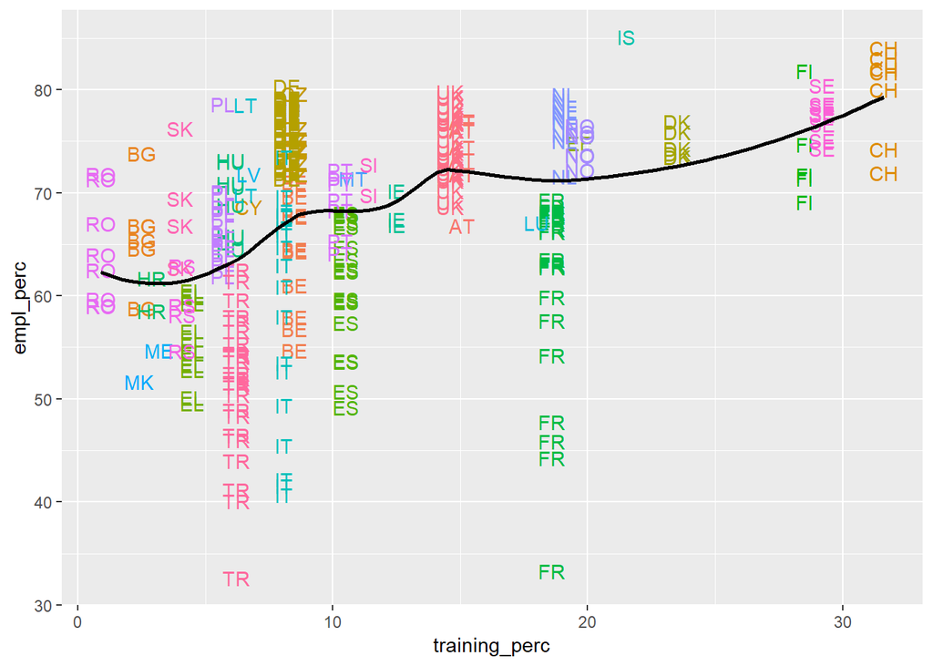

```r
library(ggplot2)
INNER_UNITE %>%
  ggplot(aes(x = training_perc, y = empl_perc, col = COUNTRY)) +
    geom_text(aes(label = COUNTRY)) + geom_smooth(aes(col = NULL), alpha = 0, col = "black") +
    guides(col = "none")
```